# Plotting Tips

**Masaru Nakanotani**  
**CSPAR, UAH, Huntsville, AL 35805, USA**  
**Feb/01/2021** (Date created)  
**Feb/26/2025** (Last modified)

In this post, I show some tips to create plots using Matplotlib.  
useful sites: https://pythonmatplotlibtips.blogspot.com/, https://sabopy.com/

You can toggle input cells by clicking a prompt (i.e. In [ ]: ) or an output cell.

```python
%config InlineBackend.figure_format='retina'
from spacepy import pycdf
import math as mt
import matplotlib.pyplot as plt
import numpy as np
import scipy.fft as sf
import datetime
import bisect
import matplotlib.patches as patches
import matplotlib.dates as mdates
from IPython.display import display,Math
import matplotlib as mpl
import pandas as pd
from matplotlib.gridspec import GridSpec
import matplotlib.animation as animation
from mpl_toolkits.axes_grid1.inset_locator import zoomed_inset_axes, mark_inset
from matplotlib.ticker import ScalarFormatter
from matplotlib.colors import ListedColormap, LinearSegmentedColormap
```

## plot parameters

You need to define these different from the cell which called matplotlib.pyplot

```python
### This is optional: if you want to use a not-bulid-in font in your system, you can use this cell to read it.
### for more information: https://scentellegher.github.io/visualization/2018/05/02/custom-fonts-matplotlib.html ###
from matplotlib import font_manager

font_dirs  = ['/Library/Fonts/']
font_files = font_manager.findSystemFonts(fontpaths=font_dirs)

for font_file in font_files:
    font_manager.fontManager.addfont(font_file)

# set font
mpl.rcParams['font.family'] = 'Avenir Next World'
```

```python
color='#2c2c2c'
#color='#ffffff'
#mpl.rcParams['font.family'      ]='Helvetica Neue'#, 'Times New Roman'
mpl.rcParams['mathtext.default' ]='regular'
mpl.rcParams["mathtext.fallback"]=None

#mpl.rcParams['font.family'      ]='Avenir', 'Times'
#mpl.rcParams['mathtext.fontset'] = 'custom'
#mpl.rcParams['mathtext.default' ]='rm'
#mpl.rcParams['mathtext.rm'] = 'Avenir'
mpl.rcParams['font.size'        ]=15
mpl.rcParams['figure.figsize'   ]=(4,2)
mpl.rcParams['figure.dpi'       ]=180
mpl.rcParams['axes.linewidth'   ]=1.2
mpl.rcParams['xtick.major.size' ]=5
mpl.rcParams['xtick.minor.size' ]=4
mpl.rcParams['ytick.major.size' ]=5
mpl.rcParams['ytick.minor.size' ]=3
mpl.rcParams['xtick.major.width']=1
mpl.rcParams['ytick.major.width']=1
mpl.rcParams['xtick.direction'  ]='out'
mpl.rcParams['ytick.direction'  ]='out'
mpl.rcParams['axes.facecolor'   ]='None'
mpl.rcParams['figure.facecolor' ]='None'
mpl.rcParams['axes.edgecolor'   ]=color
mpl.rcParams['xtick.color'      ]=color
mpl.rcParams['ytick.color'      ]=color
mpl.rcParams['axes.labelcolor'  ]=color
mpl.rcParams['text.color'       ]=color
mpl.rcParams['patch.edgecolor'  ]=color
mpl.rcParams['savefig.bbox'     ]='tight'
mpl.rcParams['animation.html'   ]='jshtml'
mpl.rcParams['animation.embed_limit'] = 256  # Set limit to 256MB


###color scheme for lines: https://www.nature.com/articles/nmeth.1618 ###
from cycler import cycler
line_cycler   = (cycler(color    =[color, '#e69f00', '#56b4e9', '#009e73', '#f0e442', '#0072b2', '#d55e00', '#cc79a7']))
#line_cycler   = (cycler(color    =[color, color, color, color])+
#                 cycler(linestyle=["-"  , "--" , "-." , ":"  ]))
mpl.rcParams['axes.prop_cycle']=line_cycler
#########################################################################
```

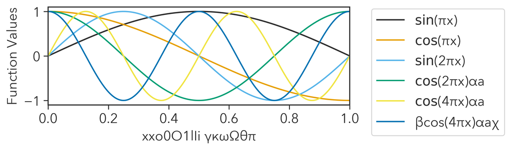

```python
x = np.linspace(0., 1, 200)

plt.rc("axes", prop_cycle=line_cycler)
plt.figure(figsize=(6, 2))
plt.plot(x,   np.sin(np.pi*x), label=r"$\sin(\pi x)$")
plt.plot(x,   np.cos(np.pi*x), label=r"$\cos(\pi x)$")
plt.plot(x, np.sin(2*np.pi*x), label=r"$\sin(2\pi x)$")
plt.plot(x, np.cos(2*np.pi*x), label=r"$\cos(2\pi x) \alpha a$")
plt.plot(x, np.sin(4*np.pi*x), label=r"$\cos(4\pi x) \alpha a$")
plt.plot(x, np.cos(4*np.pi*x), label=r"$\beta cos(4\pi x) \alpha a \chi$")
plt.legend(bbox_to_anchor=(1.05, 1.05))
plt.xlabel(r"$x$xo0O1lIi $\gamma\kappa\omega\Omega\theta\pi$")
plt.xlim(x[0], x[-1])
plt.ylabel("Function Values")
plt.show()
```

## 3D surface plot

https://stackoverflow.com/questions/36046338/contourf-on-the-faces-of-a-matplotlib-cube https://matplotlib.org/stable/gallery/mplot3d/box3d.html#sphx-glr-gallery-mplot3d-box3d-py

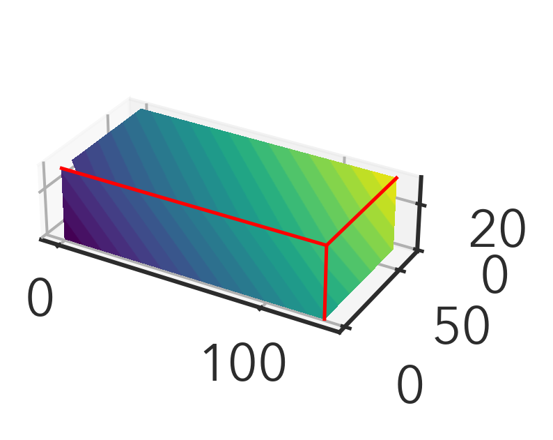

```python
def plot_cube_faces(arr, ax):
    x0 = np.arange(arr.shape[2])
    y0 = np.arange(arr.shape[1])
    z0 = np.arange(arr.shape[0])
    z, y, x = np.meshgrid(z0, y0, x0,indexing='ij')

    xmax, ymax, zmax = max(x0), max(y0), max(z0)
    xmin, ymin, zmin = min(x0), min(y0), min(z0)
    vmin, vmax = np.min(arr), np.max(arr)

    ax.contourf(x[0,:,:],y[0,:,:],arr[-1,:,:],100,zorder=-1,
                zdir='z',offset=zmax,vmin=vmin,vmax=vmax)
    ax.contourf(x[:,0,:],arr[:,0,:],z[:,0,:],100,zorder=-1,
                zdir='y',offset=0,vmin=vmin,vmax=vmax)
    ax.contourf(arr[:,:,-1],y[:,:,0],z[:,:,0],100,zorder=-1,
                zdir='x',offset=xmax,vmin=vmin,vmax=vmax)
    edges_kw = dict(color='r', linewidth=1, zorder=1e3)
    ax.plot([xmax, xmax], [ymin, ymax], zmax, **edges_kw)
    ax.plot([xmin, xmax], [ymin, ymin], zmax, **edges_kw)
    ax.plot([xmax, xmax], [ymin, ymin], [zmin, zmax], **edges_kw)

x0 = np.arange(128)
y0 = np.arange(64)
z0 = np.arange(32)
z, y, x = np.meshgrid(z0, y0, x0,indexing='ij')
arr = (x + y + z) // 10
fig = plt.figure(figsize=(2,2))
ax = fig.add_subplot(111, projection='3d')
ax.set_box_aspect(aspect = (4,2,1))
plot_cube_faces(arr, ax)
plt.show()
```

## Your own colormap

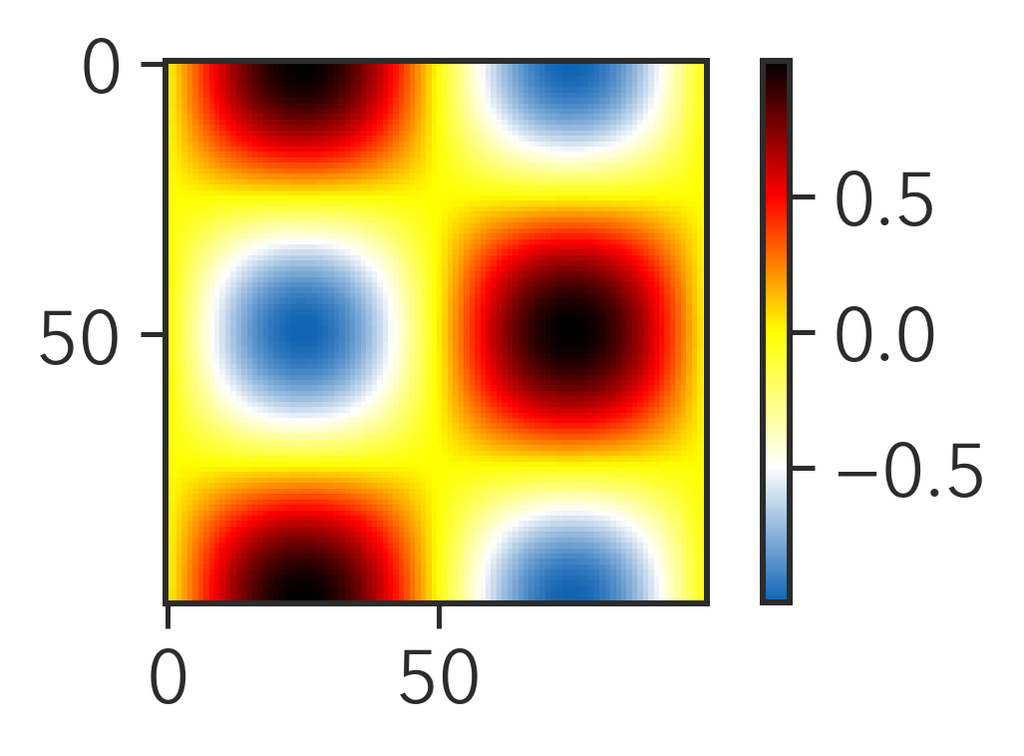

```python
### you need "LinearSegmentedColormap"
#from matplotlib.colors import LinearSegmentedColormap
colors = ['#1164B4', 'white', 'yellow', 'red','black']
cmap1 = LinearSegmentedColormap.from_list("mycmap", colors)

x=np.linspace(0,2*np.pi,100); y=np.linspace(0,2*np.pi,100)

X,Y=np.meshgrid(x,y)
Z=np.sin(X)*np.cos(Y)

plt.imshow(Z,cmap=cmap1)
plt.colorbar()

plt.show()
```

## Line and marker styles

http://scipy-lectures.org/intro/matplotlib/auto_examples/options/plot_linestyles.html

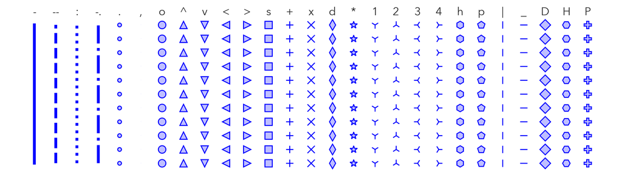

```python
def linestyle(ls, i):
    X = i * 1 * np.ones(11)
    Y = np.arange(11)
    plt.plot(X, Y, ls, color=(.0, .0, 1, 1), lw=3, ms=8,
            mfc=(.75, .75, 1, 1), mec=(0, 0, 1, 1))
    plt.text(1 * i, 10.5, ls, rotation=0, fontsize=12, va='bottom', ha='center')

linestyles = ['-', '--', ':', '-.', '.', ',', 'o', '^', 'v', '<', '>', 's',
              '+', 'x', 'd', '*', '1', '2', '3', '4', 'h', 'p', '|', '_', 'D', 'H', 'P']

n_lines = len(linestyles)

size = 40 * n_lines, 300
dpi = 120
figsize= size[0] / float(dpi), size[1] / float(dpi)
fig = plt.figure(figsize=figsize, dpi=dpi)
plt.axes([0, 0.01, 1, .9], frameon=False)

for i, ls in enumerate(linestyles):
    linestyle(ls, i)

#plt.xlim(-.2, .2 + 1*n_lines)
plt.xticks([])
plt.yticks([])

plt.show()
```

## Multiple polar plots

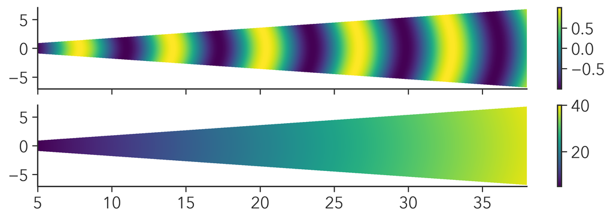

```python
fig, ax = plt.subplots(nrows=2,ncols=1,figsize=(10,3),sharex='all')

nx=1600
ny=64
r =np.linspace(5,40,nx)
th=np.linspace(-10,10,ny,endpoint=True)/180*np.pi
R,Th=np.meshgrid(r,th)
X=R*np.cos(Th)
Y=R*np.sin(Th)
im1=ax[0].pcolormesh(X,Y,np.sin(R),shading='auto')
ax[0].set_aspect('auto')
ax[0].spines['right'].set_color('none')
ax[0].spines['top'  ].set_color('none')
cb1=fig.colorbar(im1, ax=ax[0])

im2=ax[1].pcolormesh(X,Y,R,shading='auto')
ax[1].set_aspect('auto')
ax[1].spines['right'].set_color('none')
ax[1].spines['top'  ].set_color('none')
ax[1].set_xlim(5,38)
cb2=fig.colorbar(im2, ax=ax[1])
plt.show()
```

## Change color according to values

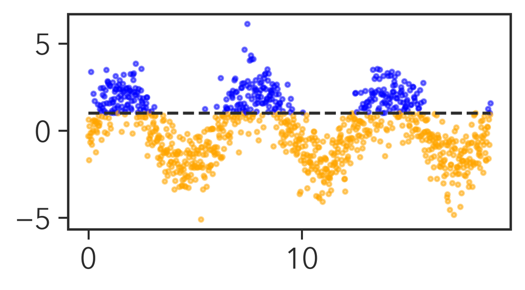

```python
from matplotlib import colors

x=np.linspace(0,6*np.pi,1000)
y=2*np.sin(x)+np.random.randn(1000)

# make a color map of fixed colors
cmap = colors.ListedColormap(['orange', 'blue'])
bounds=([-5,1,5])
norm = colors.BoundaryNorm(bounds, cmap.N)
plt.scatter(x,y,s=5,c=y,cmap=cmap,norm=norm,alpha=0.5)
#plt.colorbar()
plt.hlines(1,x.min(),x.max(),linestyles='dashed')
### another way ###
#plt.scatter(x[y< 1],y[y< 1],s=5,c='orange',alpha=0.5)
#plt.scatter(x[y>=1],y[y>=1],s=5,c='blue'  ,alpha=0.5)
###################
plt.show()
```

## Step plot

Using the 'drawstyle' parameter of plt.plot, we can obtain the same plot.

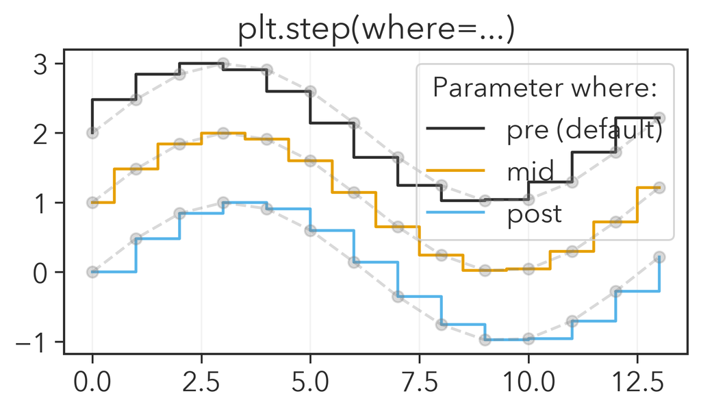

```python
x = np.arange(14)
y = np.sin(x / 2)

fig=plt.figure(figsize=(6,3))
plt.step(x, y + 2, where='pre', label='pre (default)')
plt.plot(x, y + 2, 'o--', color='grey', alpha=0.3)

plt.step(x, y + 1, where='mid', label='mid')
plt.plot(x, y + 1, 'o--', color='grey', alpha=0.3)

plt.step(x, y, where='post', label='post')
plt.plot(x, y, 'o--', color='grey', alpha=0.3)

plt.grid(axis='x', color='0.95')
plt.legend(title='Parameter where:')
plt.title('plt.step(where=...)')
plt.show()
```

## Markevery plot

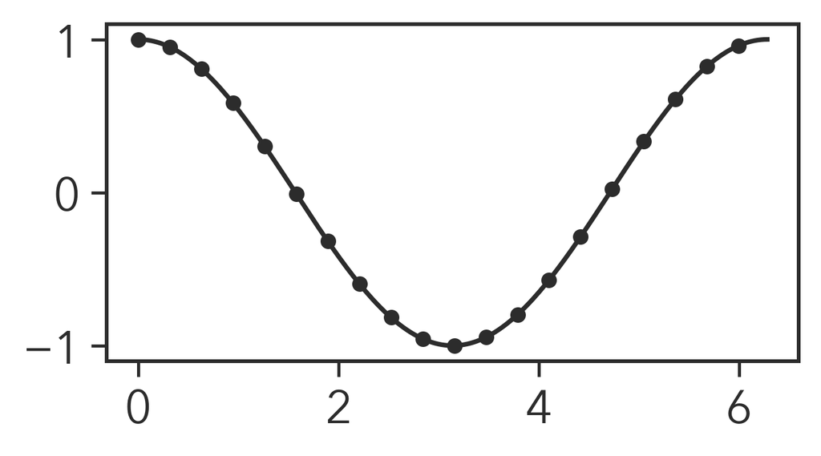

```python
x = np.linspace(0, 2*np.pi, 200)
y = np.cos(x)

fig,ax=plt.subplots()
ax.plot(x, y, 'o', ls='-', ms=4, markevery=10)
plt.show()
```

## Ticks control

https://sabopy.com/py/matplotlib-12/

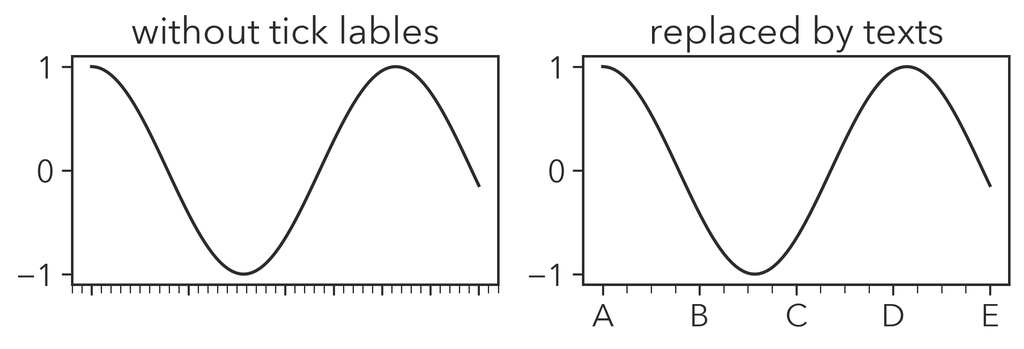

```python
import matplotlib.ticker as ticker
x=np.linspace(0,8,100)
y=np.cos(x)

fig,ax=plt.subplots(ncols=2,figsize=(8,2))
ax[0].plot(x,y)
ax[0].set_xticks([0, 2, 4,5, 6, 7,8])
ax[0].set_xticklabels([])
ax[0].xaxis.set_minor_locator(ticker.MultipleLocator(0.2))
ax[0].set_title('without tick lables')
ax[1].plot(x,y)
ax[1].set_xticks([0, 2, 4, 6, 8])
ax[1].set_xticklabels(['A', 'B', 'C', 'D', 'E'])
ax[1].xaxis.set_minor_locator(ticker.MultipleLocator(0.5))
ax[1].set_title('replaced by texts')
plt.show()
```

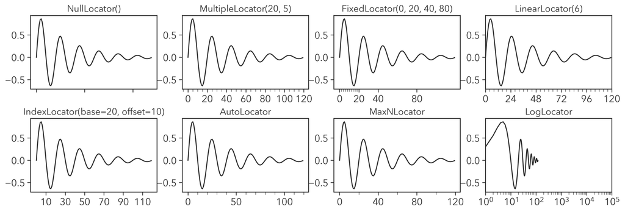

```python
import matplotlib.ticker as ticker

t = np.arange(0.0, 120.0, 1)
y = np.sin(0.1 * np.pi * t) * np.exp(-t * 0.03)

fig,ax=plt.subplots(nrows=2,ncols=4,figsize=(16,5))
fig.subplots_adjust(hspace=0.4)

ax[0,0].plot(t,y)
#ax[0,0].xaxis.set_major_locator(ticker.NullLocator())
#ax[0,0].xaxis.set_minor_locator(ticker.NullLocator())
ax[0,0].xaxis.set_major_formatter(ticker.NullFormatter())
ax[0,0].set_title( "NullLocator()", fontsize=14)

ax[0,1].plot(t,y)
ax[0,1].xaxis.set_major_locator(ticker.MultipleLocator(20))
ax[0,1].xaxis.set_minor_locator(ticker.MultipleLocator(5))
ax[0,1].set_title( "MultipleLocator(20, 5)", fontsize=14)
#ax[0,1].xaxis.set_major_formatter(ticker.NullFormatter())

majors = [0, 20, 40, 80]
minors = np.linspace(0, 20, 11)[1:-1] #array([ 2.,  4.,  6.,  8., 10., 12., 14., 16., 18.])
ax[0,2].plot(t,y)
ax[0,2].xaxis.set_major_locator(ticker.FixedLocator(majors))
ax[0,2].xaxis.set_minor_locator(ticker.FixedLocator(minors))
ax[0,2].set_title( "FixedLocator(0, 20, 40, 80)", fontsize=14)

ax[0,3].plot(t,y)
ax[0,3].set_xlim(0,120)
ax[0,3].xaxis.set_major_locator(ticker.LinearLocator(6))
ax[0,3].xaxis.set_minor_locator(ticker.LinearLocator(31))
ax[0,3].set_title( "LinearLocator(6)", fontsize=14)

ax[1,0].plot(t,y)
ax[1,0].xaxis.set_major_locator(ticker.IndexLocator(base=20, offset=10))
ax[1,0].set_title( "IndexLocator(base=20, offset=10)", fontsize=14)

ax[1,1].plot(t,y)
ax[1,1].xaxis.set_major_locator(ticker.AutoLocator())
ax[1,1].xaxis.set_minor_locator(ticker.AutoMinorLocator())
ax[1,1].set_title( "AutoLocator", fontsize=14)

ax[1,2].plot(t,y)
ax[1,2].xaxis.set_major_locator(ticker.MaxNLocator(4))
ax[1,2].xaxis.set_minor_locator(ticker.MaxNLocator(8))
ax[1,2].set_title( "MaxNLocator", fontsize=14)

ax[1,3].plot(t,y)
ax[1,3].set_xlim(10**0, 10**5)
ax[1,3].set_xscale('log')
ax[1,3].xaxis.set_major_locator(ticker.LogLocator(base=10.0,subs=(1,10), numticks=7))
#ax[1,3].xaxis.set_minor_locator(ticker.LogLocator(base=10.0,subs=(1,10), numticks=7))
ax[1,3].xaxis.set_minor_locator(ticker.LogLocator(base=10.0,subs=np.arange(2, 10)*.1,numticks=7))
ax[1,3].xaxis.set_minor_formatter(ticker.NullFormatter())
ax[1,3].set_title( "LogLocator", fontsize=14)

plt.show()
```

## Combine axes

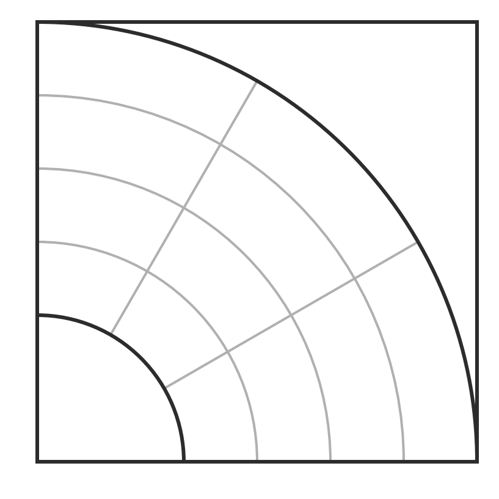

```python
fig=plt.figure()

ax1=fig.add_axes([0,0,1,1], label='cartesian', projection=None)
ax1.set_xlim(0,10)
ax1.set_ylim(0,10)
ax1.set_xticks([])
ax1.set_yticks([])
ax1.set_aspect('equal')

ax2=fig.add_axes([0,0,1,1], label='polar'    , projection='polar')
ax2.set_ylim(2,10)
ax2.set_thetamin(0)
ax2.set_thetamax(90)
ax2.set_rorigin(-2)
ax2.set_xticklabels([])
ax2.set_yticklabels([])
#ax2.set_rlabel_position(22.5)  # Move radial labels away from plotted line
ax2.grid(True)
```

## Annotate

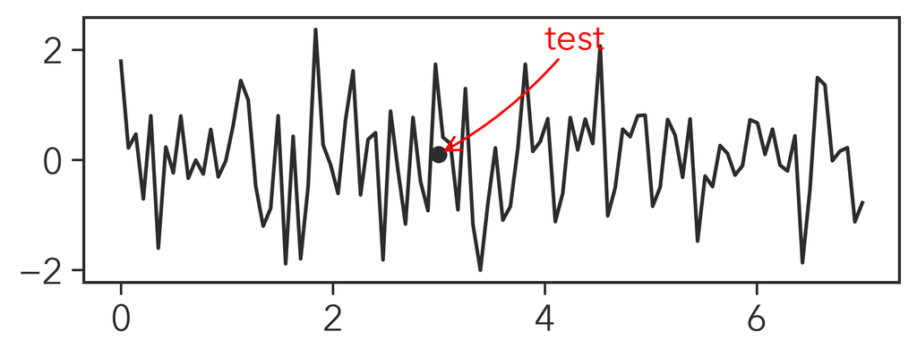

```python
fig,ax = plt.subplots(figsize=(6,2))

x = np.linspace(0,7,100)
y = np.random.randn(100)
ax.plot(x,y)
ax.scatter(3,0.1)

ax.annotate('test', xy=(3,0.1), xytext=(4,2),color='r',
            arrowprops=dict(arrowstyle='->',connectionstyle='arc3, rad=-0.1',color='r'),
            bbox=dict(boxstyle='round,pad=-0.07', fc='none', ec='none'),)

plt.show()
```

## Bar plot

https://pythonmatplotlibtips.blogspot.com/2018/11/sample-number-stacked-barplot-python-matplotlib.html

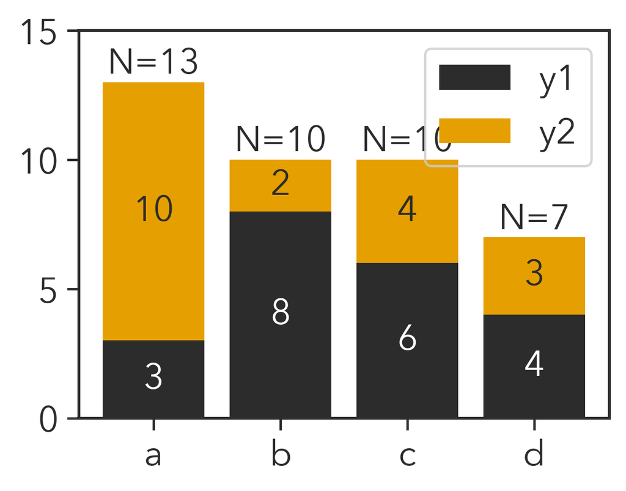

```python
x = ["a","b","c","d"]
y1 = np.array([3,8,6,4])
y2 = np.array([10,2,4,3])

plt.figure(figsize=(4,3))

plt.bar(x, y1, label='y1')
plt.bar(x, y2 ,bottom=y1,label='y2')

# add text annotation corresponding to the values of each bar.
for xpos, ypos, yval in zip(x, y1/2, y1):
    plt.text(xpos, ypos, yval, ha="center", va="center",color='w')
for xpos, ypos, yval in zip(x, y1+y2/2, y2):
    plt.text(xpos, ypos, yval, ha="center", va="center")

# add text annotation corresponding to the "total" value of each bar
for xpos, ypos, yval in zip(x, y1+y2, y1+y2):
    plt.text(xpos, ypos, "N=%d"%yval, ha="center", va="bottom")

plt.ylim(0,15)

plt.legend()
plt.show()
```

## Aligned y-labels

https://pythonmatplotlibtips.blogspot.com/2018/11/another-way-to-align-two-ylabels-python-matplotlib.html#more

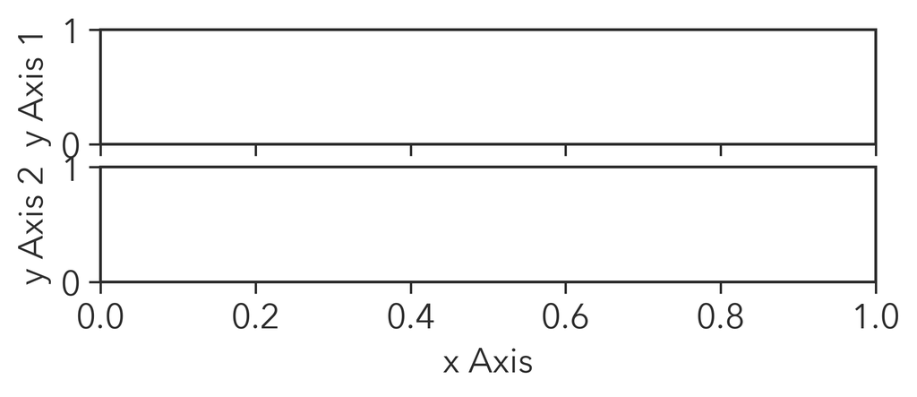

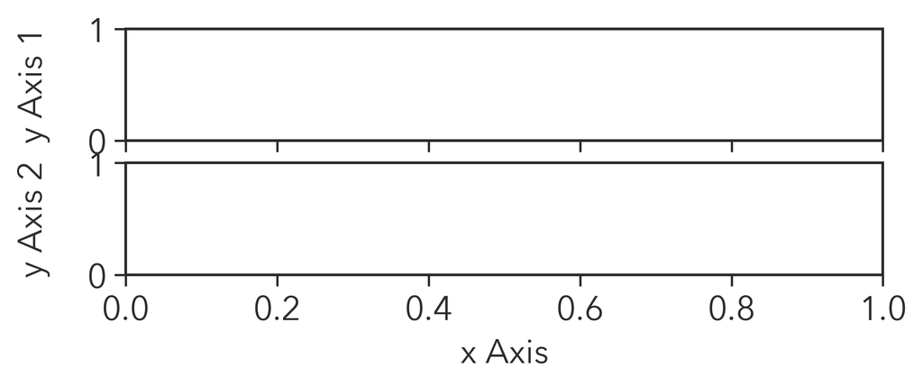

```python
fig = plt.figure(figsize=(6,2))
ax1 = fig.add_subplot(2,1,1)
ax2 = fig.add_subplot(2,1,2,sharex=ax1)
ax1.set_ylabel("y Axis 1")
ax2.set_ylabel("y Axis 2")
ax2.set_xlabel("x Axis")
plt.setp(ax1.get_xticklabels(),visible=False)
fig.align_ylabels([ax1,ax2])
plt.show()

fig = plt.figure(figsize=(6,2))
ax1 = plt.subplot(2,1,1)
ax2 = plt.subplot(2,1,2,sharex=ax1)
ax1.set_ylabel("y Axis 1")
ax2.set_ylabel("y Axis 2")
ax2.set_xlabel("x Axis")
ax1.yaxis.set_label_coords(-0.1,0.5)
ax2.yaxis.set_label_coords(-0.1,0.5)
plt.setp(ax1.get_xticklabels(),visible=False)
plt.show()
```

## Streamplot

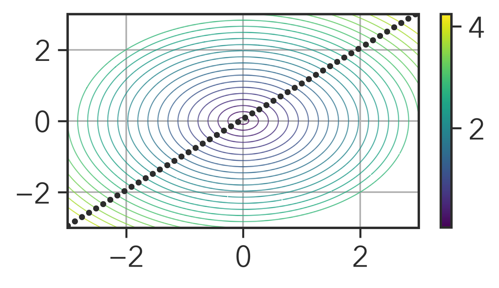

```python
x,y = np.linspace(-3,3,100),np.linspace(-3,3,100)
X,Y = np.meshgrid(x,y)
U = -Y
V = X
Z=np.sqrt(X**2+Y**2)

stream_points = np.array((3*(1-2*np.random.rand(100)), 3*(1-2*np.random.rand(100)))).reshape(-1,2)
stream_points = np.array((np.linspace(-3,3,100), np.linspace(-3,3,100))).reshape(-1,2)
fig=plt.figure(figsize=(4,2))
plt.streamplot(X,Y,U,V,color=Z,start_points=stream_points,density=30,linewidth=0.5,arrowstyle='-')
plt.colorbar()
#plt.streamplot(X,Y,U,V,density=2)
plt.plot(stream_points[:,0],stream_points[:,1],'o',ms=2)
plt.grid()
plt.show()
```

## Scientific notation

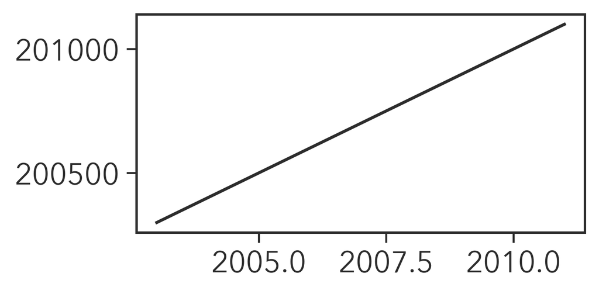

```python
fig, ax = plt.subplots()
ax.plot(range(2003,2012,1),range(200300,201200,100))
ax.ticklabel_format(useOffset=False)
plt.show()
```

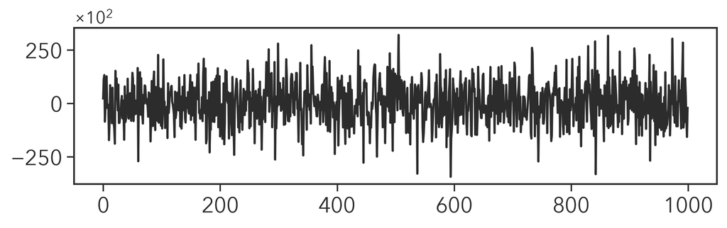

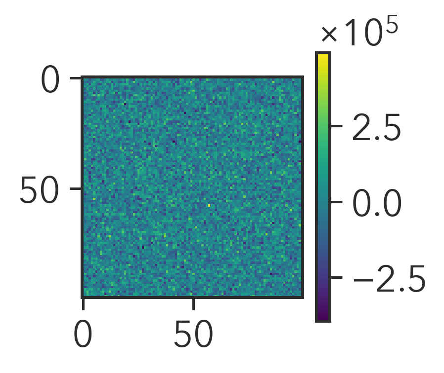

```python
fig,ax=plt.subplots(figsize=(8,2))
ax.plot(np.random.randn(1000)*1e4)
ax.yaxis.set_major_formatter(ScalarFormatter(useMathText=True))
ax.ticklabel_format(axis='y', style='sci', scilimits=(2,2))
ax.yaxis.offsetText.set_fontsize(12)
plt.show()

fig,ax=plt.subplots(figsize=(2,2))
im1=ax.imshow(np.random.randn(100,100)*1e5)
fmt=ScalarFormatter(useMathText=True)
fmt.set_powerlimits((0,0))
cb=fig.colorbar(im1,ax=ax,format=fmt)
cb.ax.yaxis.set_offset_position('left')
cb.update_ticks()
plt.show()
```

## Sky map

You can also use cartopy for more flexible maps.

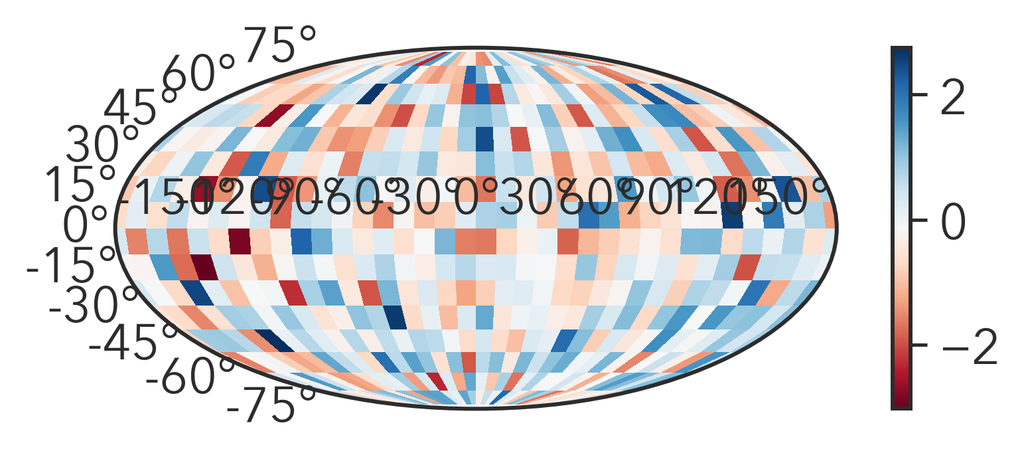

```python
fig = plt.figure(figsize=(6,2))
ax = fig.add_subplot(111, projection='mollweide')
lon = np.linspace(-np.pi, np.pi,36)
lat = np.linspace(-np.pi/2., np.pi/2.,18)
arr = np.random.randn(18, 36)
im = ax.pcolormesh(lon,lat,arr,shading='nearest',cmap='RdBu')
fig.colorbar(im,ax=ax)
plt.show()
```

## Ticks for both sides

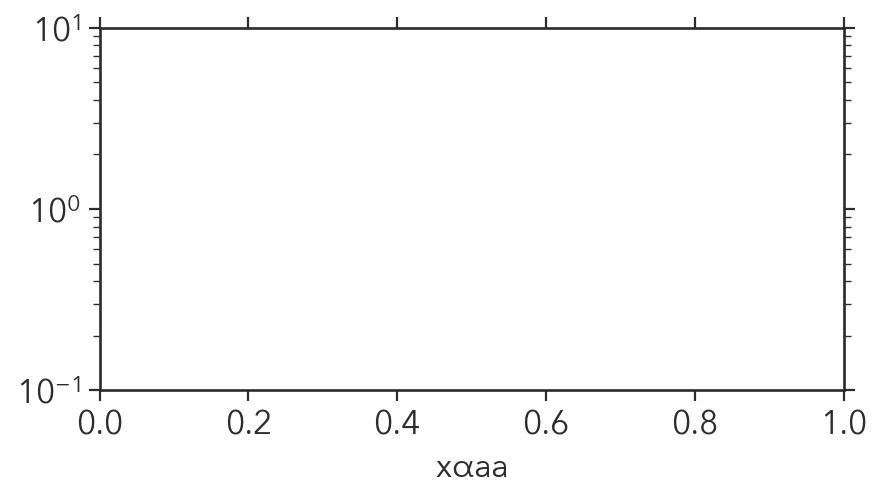

```python
fig, ax = plt.subplots(nrows=1,ncols=1,figsize=(6,3),sharex='all',dpi=80)

ax.xaxis.set_tick_params(which='major',  top='on')
ax.yaxis.set_tick_params(which='both' ,right='on')

ax.set_ylim(0.1,10)
ax.set_yscale('log')
ax.set_xlabel(r'x$\alpha a$a')
plt.show()
```

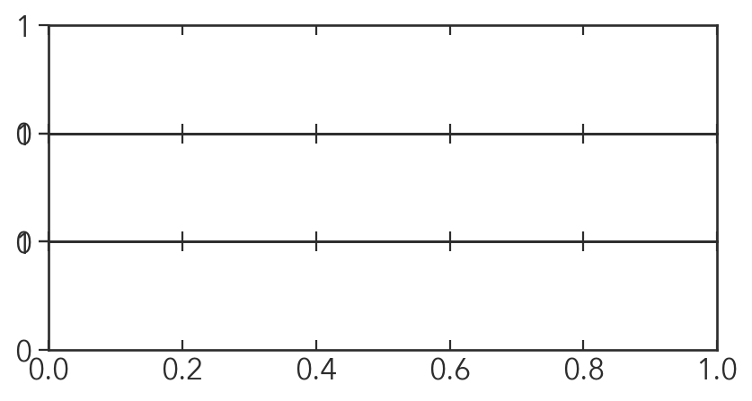

```python
fig, ax = plt.subplots(nrows=3,ncols=1,figsize=(6,3),sharex='all',dpi=80)
plt.subplots_adjust(hspace=0.)
for ic in range(3):
    ax[ic].xaxis.set_tick_params(which='major',  top='on', direction='in', length=5, width=1)
plt.show()
```

## Heat map with log-scaled bins

It is better to use 'pcolormesh' rather than 'imshow'

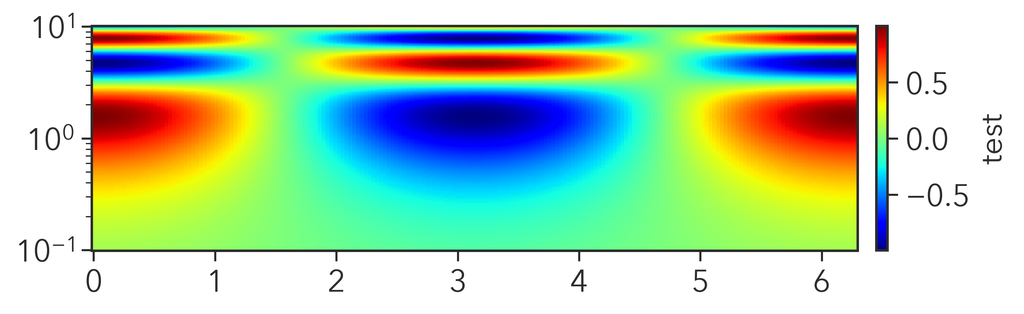

```python
x=np.linspace(0,2*np.pi,200)
y=np.logspace(-1,1,200)
X,Y=np.meshgrid(x,y)
Z=np.cos(X)*np.sin(Y)

fig,ax=plt.subplots(figsize=(8,2))
im1=ax.pcolormesh(X,Y,Z,cmap='jet',shading='auto')
ax.set_yscale('log')
fig.colorbar(im1,ax=ax,label='test',pad=0.02)
plt.show()
```

## Shaded region over several panels

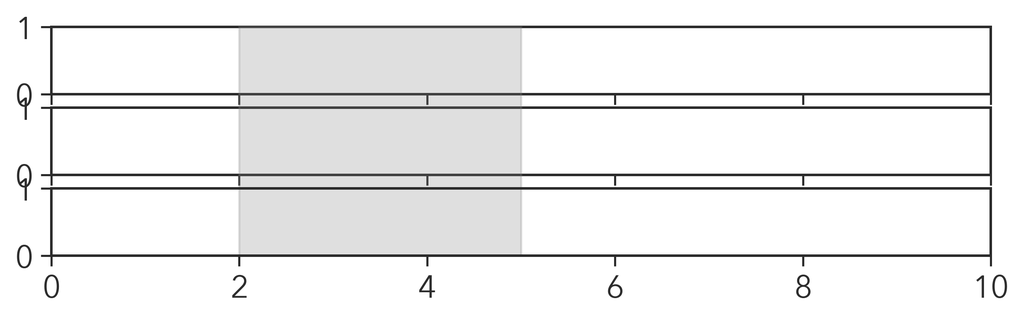

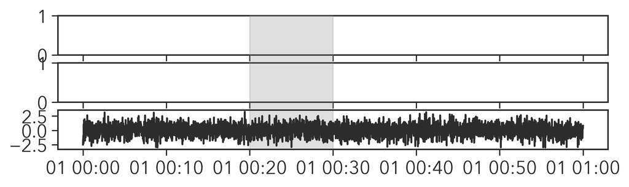

```python
#### for observational data ###
#data = cdas.get_data(
#    'sp_phys',
#    'STA_L1_MAG_RTN',
#    datetime.datetime(2010, 1, 1, 0,  0,  0),
#    datetime.datetime(2010, 1, 1, 1,  0,  1),
#    ['BFIELD'],
#    cdf=True # download data in CDF format
#)
#
#### convert to the dataframe of pandas ###
#d = {'BR': data['BFIELD'][:,0], 'BT': data['BFIELD'][:,1], 'BN':data['BFIELD'][:,2]}
#df0 = pd.DataFrame(data=d,index=data['Epoch'][:])
#df0.index.name='time'
###########################################

dates = pd.date_range(start='2010-01-01', periods=3601,  freq='S')
d={'R':np.linspace(0,100,3601),'BR': np.random.randn(3601), 'BT': np.random.randn(3601), 'BN': np.random.randn(3601)}
df0=pd.DataFrame(data=d, index=dates)
df0.index.name='time'
#print(df0)

fig, ax = plt.subplots(nrows=3, sharex=True, figsize=(8, 2))

ax[2].set_xlim(0,10)

### add a rectangle patch ###
rect = patches.Rectangle((2, 0), 3, 3+2*fig.subplotpars.hspace, color='grey',alpha=.25, clip_on=False,transform=ax[2].get_xaxis_transform())
ax[2].add_patch(rect)
#############################
plt.show()


### date time format ###
fig, ax = plt.subplots(nrows=3, sharex=True, figsize=(8, 2))
ax[2].plot(df0.index[:], df0['BR'][:])

### add a rectangle patch ###
#start='2010-01-01 00:20:00'
#end  ='2010-01-01 00:30:00'
#startplt = mdates.date2num(start)
#endplt   = mdates.date2num(end)
#rect = patches.Rectangle((startplt, 0), endplt-startplt, 3+2*fig.subplotpars.hspace, color='grey',alpha=.25, clip_on=False, transform=ax[2].get_xaxis_transform())

start = datetime.datetime(2010, 1, 1, 0,20,0)
end   = datetime.datetime(2010, 1, 1, 0,30,0)
rect = patches.Rectangle((start, 0), end-start, 3+2*fig.subplotpars.hspace, color='grey',alpha=.25, clip_on=False, transform=ax[2].get_xaxis_transform())
ax[2].add_patch(rect)
#############################

#ax[2].set_xlim(start,end)

plt.show()
```

## Vertical line over several panels

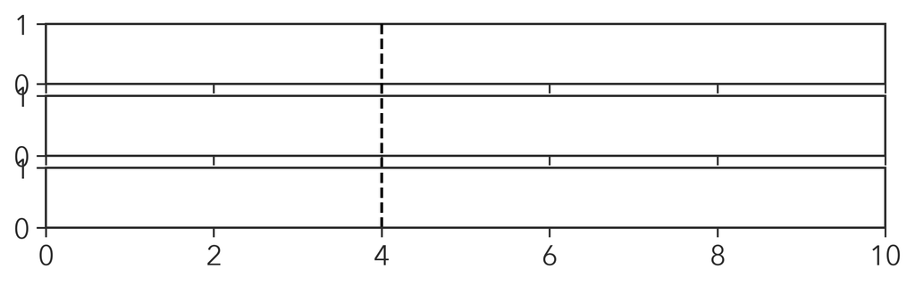

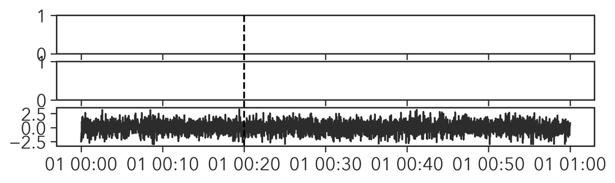

```python
fig, ax = plt.subplots(nrows=3, sharex=True, figsize=(8, 2))
ax[2].set_xlim(0,10)
ax[2].axvline(4, 0, 3+2*fig.subplotpars.hspace, ls='dashed', color='k', clip_on=False)
plt.show()

### for observation ###
fig, ax = plt.subplots(nrows=3, sharex=True, figsize=(8, 2))
start = datetime.datetime(2010, 1, 1, 0,20,0)
ax[2].plot(df0.index[:], df0['BR'][:])
ax[2].axvline(start, 0, 3+2*fig.subplotpars.hspace, ls='dashed', color='k', clip_on=False)
plt.show()
```

## Crossed axes and equal aspect

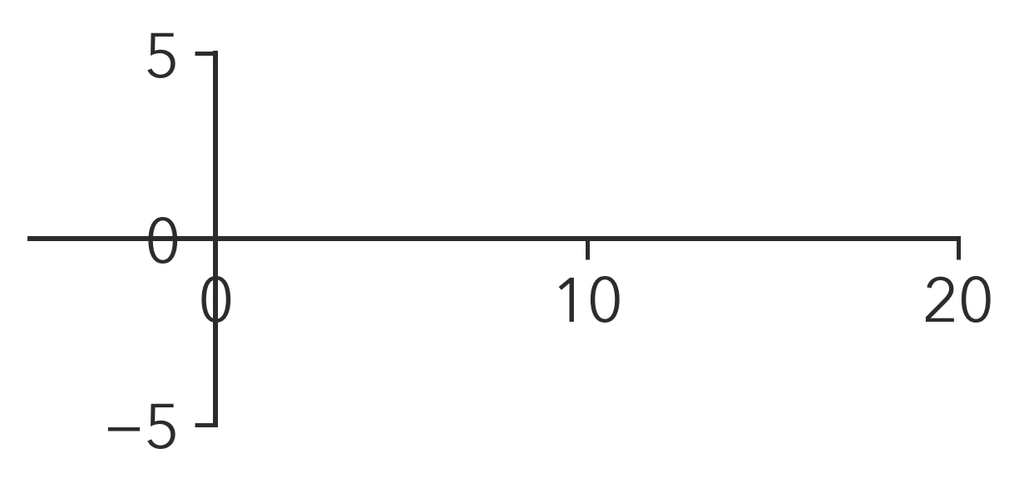

```python
fig,ax=plt.subplots(nrows=1,ncols=1,figsize=(4,2))

# Move left y-axis and bottim x-axis to centre, passing through (0,0)
ax.spines['left'].set_position('zero')
ax.spines['bottom'].set_position('center')

# Eliminate upper and right axes
ax.spines['right'].set_color('none')
ax.spines['top'].set_color('none')

# Show ticks in the left and lower axes only
ax.xaxis.set_ticks_position('bottom')
ax.yaxis.set_ticks_position('left')

ax.set_xlim(-5,20)
ax.set_ylim(-5,5)

ax.set_aspect('equal')

plt.show()
```

## Log scale color map

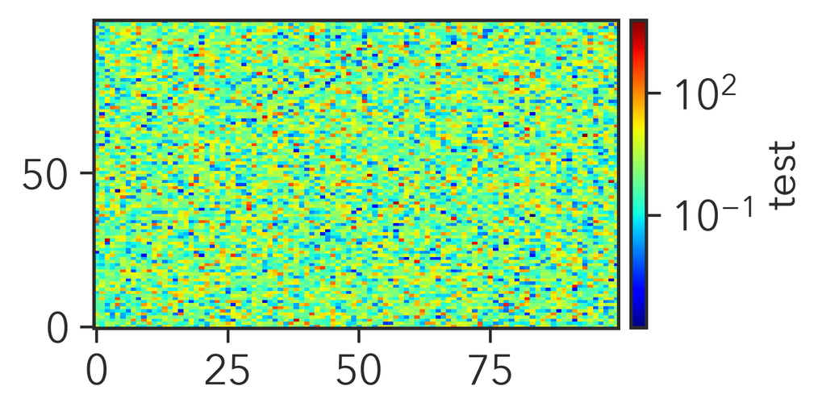

```python
fig,ax=plt.subplots(figsize=(4,2))
im1=ax.imshow(10**np.random.randn(100,100),cmap='jet',aspect='auto',origin='lower', norm=mpl.colors.LogNorm())
fig.colorbar(im1,ax=ax,label='test',pad=0.02)
plt.show()
```

## Colorbar scale of date

[figure not shown]

```python
#### plot figure ###
fig, ax = plt.subplots(ncols=1, figsize=(3,3))

N_TICKS = 12
cmap = plt.cm.get_cmap('jet', N_TICKS)    # 11 discrete colors

smap = ax.scatter(df0['BR'][:],df0['BT'][:],c=df0.index,cmap=cmap,marker='o',s=10,alpha=0.8)

smap.set_facecolor("none")

indexes = [df0['2010-01-01 00:00'].index[0], df0['2010-01-01 00:15'].index[0], df0['2010-01-01 00:30'].index[0], df0['2010-01-01 00:45'].index[0], df0['2010-01-01 01:00'].index[0]]

cb = fig.colorbar(smap, ax=ax, orientation='vertical', ticks= df0.loc[indexes].index.astype(int), label='hh:mm')

cb.ax.set_yticklabels([index.strftime('%H:%M') for index in indexes])

ax.set_xlabel(r'$B_R$ [nT]')
ax.set_ylabel(r'$B_T$ [nT]')

plt.show()
```

## X label time format

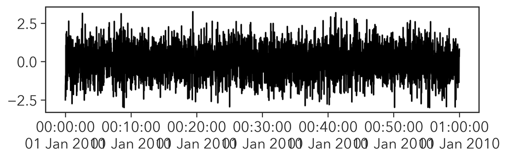

```python
### plot figure ###
fig, ax = plt.subplots(figsize=(8,2))

ax.plot(df0.index, df0['BR'][:],'k')

myfmt=mdates.DateFormatter('%H:%M:%S\n%d %b %Y')
ax.xaxis.set_major_formatter(myfmt)

plt.show()
```

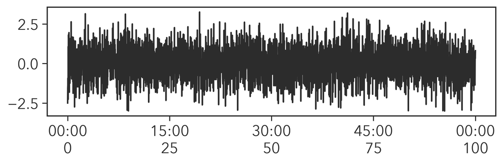

```python
nt=len(df0)
### date time format ###
fig, ax = plt.subplots(nrows=1, sharex=True, figsize=(8, 2))
ax.plot(df0.index[:], df0['BR'][:])

ax.set_xticks([df0.index[nt//4*i] for i in range(5)])
ax.set_xticklabels(['%s\n%d' %(df0.index[nt//4*i].strftime('%M:%S'),df0['R'][nt//4*i]) for i in range(5)])

plt.show()
```